# Spatial Data Science with R: 1.

## Before we start

- Link to [course pages](http://edzer.github.com/MunichRe)
- Link to this document
- Link to [GitHub](https://github.com/edzer/MunichRe) repo

## What are spatial data?

- One could argue that all data is spatial, because how can one observe something that is *not* somewhere?
- However, only data for which the location of observation is registered, referenced, and of (some) relevance for the information contained is considered *spatial data*

## Overview

- data structures vs. data concepts
- the software landscape
- work flows; file formats
- handling attributes (properties) of geometries,
- plotting maps,
- measurement units and coordinate reference systems,
- spatiotemporal data, raster and vector data cubes

## data structures vs. data concepts

- data structures: how we represent data in the computer (or on paper)
- data concepts: what we mean by these representations

Example data structure: a vector, array, or list

Example data concept: an object, an event, a field or coverage, a trajectory, an administrative division, outcome of an election, a hurricane. We will come back to this.

## Simple features

See https://journal.r-project.org/archive/2018/RJ-2018-009/

Simple features are (a data model for) **things** that have a **geometry** and **properties**.

Simple feature geometry refers to the geometry of a simple feature.

The *simple* refers to lines (and polygon boundaries) being represented by points connected with straight lines.

For some things, this "thing data model" either works

- **badly**: *continuously* varying spatial properties, like air temperature
- **moderately well**: categorical/discrete properties varying continuously over space, such as land use

## The common geometries

- `POINT (0 1)`
- `MULTIPOINT (0 1,1 1,-1 2)`
- `LINESTRING (0 0,1 1)`
- `MULTILINESTRING ((0 0,1 1),(2 2,0 2))`
- `POLYGON ((0 0,3 0,3 3,0 3,0 0),(1 1,2 1,2 2,1 2,1 1))`
- `MULTIPOLYGON (((0 0,1 0,1 1,0 1,0 0)),((2 2,3 2,3 3,2 3,2 2)))`
- `GEOMETRYCOLLECTION(POINT(0 1), LINESTRING(0 0,1 1))`
- `POINT EMPTY`

These encodings are called *Well-known text* (WKT)

## Binary encodings for foreign I/O

Well-known binary (WKB):

```r
library(sf)
st_as_binary(st_as_sfc("POINT (0 1)"))[[1]]
```

```
##  [1] 01 01 00 00 00 00 00 00 00 00 00 00 00 00 00 00 00 00 00 f0 3f
```

```r
st_as_binary(st_as_sfc("LINESTRING (0 0,1 1)"))[[1]]
```

```
##  [1] 01 02 00 00 00 02 00 00 00 00 00 00 00 00 00 00 00 00 00 00 00 00 00
## [24] 00 00 00 00 00 00 00 00 f0 3f 00 00 00 00 00 00 f0 3f
```

WKB:

- I/O but also to GDAL, GEOS and liblwgeom
- I/O (direct) to databases,
- not human readable, but
- fast, and lossless

## Representation in R (by `sf`):

```r
str(st_as_sfc("POINT (0 1)")[[1]])
```

```
##  'XY' num [1:2] 0 1
```

```r
str(st_as_sfc("LINESTRING (0 0,1 1,2 2)")[[1]])
```

```
##  'XY' num [1:3, 1:2] 0 1 2 0 1 2
```

- `POINT` is a numeric vector
- a point set is a `matrix` (1 point per row)
- a set of anything else is a `list`
- classes disambiguate identical storage form (e.g. `LINESTRING` and `MULTIPOINT`, or `POLYGON` and `MULTILINESTRING`)

## `sf` class system

```r
class(st_linestring(rbind(c(0,0), c(1,1))))
```

```
## [1] "XY"         "LINESTRING" "sfg"
```

- *set* of single feature geometries: `sfc` (keeps bbox, CRS)

```r
class(st_sfc(st_point(c(0,1)), st_point(c(5,5)), crs = 4326))
```

```
## [1] "sfc_POINT" "sfc"
```

- *set* of single features (geom + attributes): `sf`

```r
class(st_sf(attr = "a", geom = st_sfc(st_point(c(0,1)))))
```

```
## [1] "sf"         "data.frame"
```

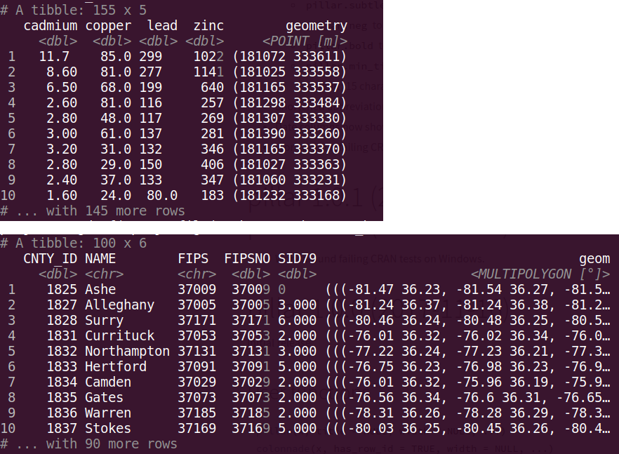

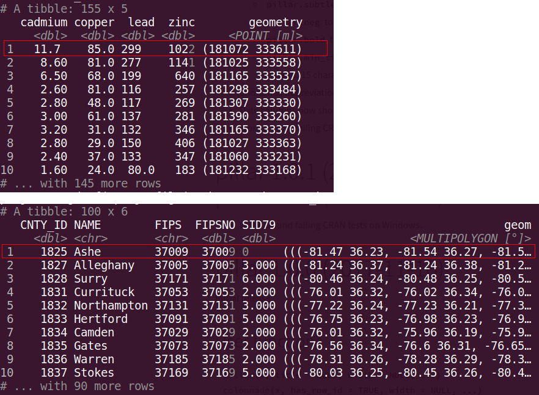

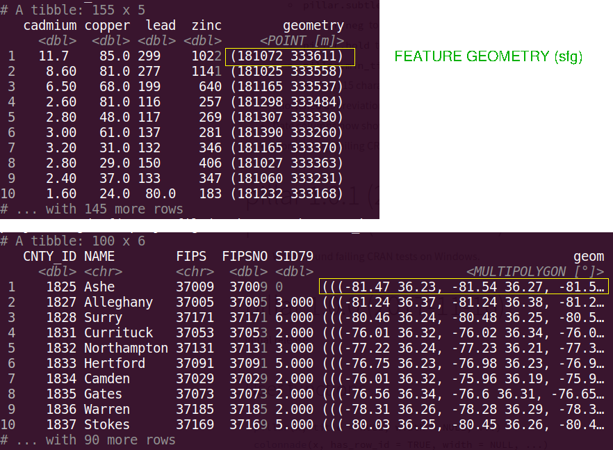

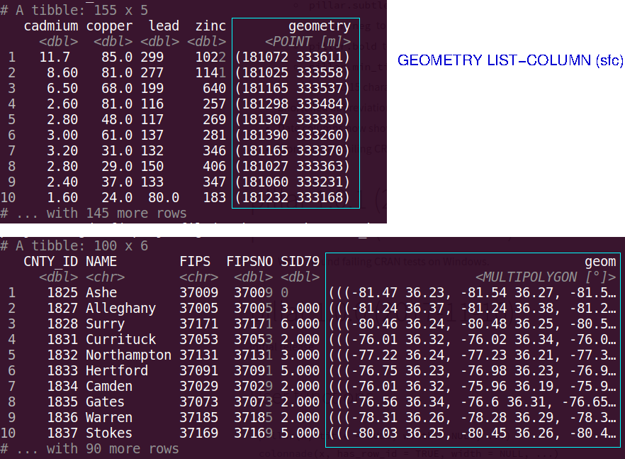

## Empty geometries

Empty geometries reflect a missing geometry. E.g.

```r
st_intersection(st_point(c(0,1)), st_point(c(2,2)))
```

```
## GEOMETRYCOLLECTION EMPTY
```

- "there is no geometry for which …"
- these are important for *type safety*
- unclear why they are typed: what makes an empty point different from an empty linestring?

## Mixes: 1. at the *single* feature level:

```r
gc = st_union(st_point(c(0,1)), st_linestring(rbind(c(0,0), c(1,1))))
gc
```

```
## GEOMETRYCOLLECTION (POINT (0 1), LINESTRING (0 0, 1 1))
```

```r
st_sf(attr = "a", geom = st_sfc(gc))
```

```
## Simple feature collection with 1 feature and 1 field
## geometry type:  GEOMETRYCOLLECTION
## dimension:      XY
## bbox:           xmin: 0 ymin: 0 xmax: 1 ymax: 1
## epsg (SRID):    NA
## proj4string:    NA
##   attr                           geom
## 1    a GEOMETRYCOLLECTION (POINT (...
```

## Mixes: 2. at the feature *set* level:

```r
g = st_sfc(st_point(c(0,1)), st_linestring(rbind(c(0,0), c(1,1))))
st_sf(attr = c("a", "b"), geom = g)
```

```
## Simple feature collection with 2 features and 1 field
## geometry type:  GEOMETRY
## dimension:      XY
## bbox:           xmin: 0 ymin: 0 xmax: 1 ymax: 1
## epsg (SRID):    NA
## proj4string:    NA
##   attr                  geom
## 1    a           POINT (0 1)
## 2    b LINESTRING (0 0, 1 1)
```

## Operations on geometries

Geometry operations can be:

- **predicates**: return `TRUE` or `FALSE`, e.g. `st_intersects`
- **measures**: return a measure (value, possibly with unit), e.g. `st_area`
- **geometry generating** operations, e.g. `st_intersection`

They have an arity:

- *unary*: operates on a single geometry, e.g. `st_area`
- *binary*: operates on a pair, e.g. `st_overlaps`
- *n-ary*: operates on a set, e.g. `st_intersection`

Chapter 5 of [Spatial Data Science](https://keen-swartz-3146c4.netlify.com/geommanip.html) details all the combinations.

If this all looks complicated, do compare it to how a GIS works.

## the R spatial package landscape: from sp to sf

The "sp stack" (2005-…) : sp, rgdal, rgeos, raster, … (sp: 550 revdeps)

The sf stack (2016-…): sf, stars, mapview, tmap, gstat, spdep, … (sf: 150 revdeps)

## sp vs. sf

comparison:

- sf can, sp cannot combine geometry types in a `GEOMETRY`
- sf can, sp cannot return `GEOMETRYCOLLECTION`
- sf can, sp cannot handle empty geometries
- sf can, sp cannot distinguish between `POLYGON` and `MULTIPOLYGON` etc.
- sp has an ambiguous data model for holes in polygons, sf doesn't
- sp's `SpatialXxxDataFrame` objects are not `data.frames`, and as a consequence, sp objects do not work well with `tidyverse` commands
- `geom_sf`: sf has full `ggplot2` support

## moving between sp and sf

```r
geom = st_sfc(st_point(0:1), st_point(1:2), crs = 4326)
x = st_sf(attr = c("a", "b"), geom = geom)
library(sp)
x.sp = as(x, "Spatial") # sf -> sp
x2 = st_as_sf(x.sp) # and back: sp -> sf
all.equal(x, x2, check.attributes = FALSE)
```

```
## [1] TRUE
```

- This works for objects that *can* be converted, and gives an error otherwise.
- `LINESTRING` and `POLYGON` return as `MULTILINESTRING` and `MULTIPOLYGON` respectively.

## Exercise (1)

- use the dataset found in `system.file("shape/nc.shp", package="sf")`
- Read this dataset with `sf::st_read` (or `sf::read_sf`)
- plot the dataset, then plot the second attribute
- try to manipulate the color scheme and color breaks
- plot the first 20 features of the dataset
- create a plot with axes
- what is the coordinate reference system of the dataset?
- For the `nc` dataset, compute the area of the polygons with `st_area`
- compare the areas with the `AREA` field in the dataset; is there a discrepancy?
- select the polygon that intersects with `POINT (-81.49826 36.4314)`
- Repeat the above steps (or similar ones) with a dataset of your own

## workflows

Typical workflow:

- read: load data from external files or database
- compute: carry out computations
- write: export results (new data "layers", summary statistics, figures)

Recommended:

- put everything in an R script
- *even better*: also put comments in the R script
- *much better*: work from R-Markdown files, write executable documents

## workflows without side effects

Avoid side effects (anything *not* in the script/R Markdown file):

- **NEVER** read .RData file at startup (rstudio option; `R --vanilla`)
- **NEVER** write .RData at end (rstudio option; `R --vanilla`)
- do not put side effects options in .Renviron / .Rprofile (I use it for graphics options or user credentials)

## Reproducible workflows

- avoid using `setwd()`, at all times
- avoid using `rm(ls())` at the start of the script, but assume a clean workspace
- put all `library(xxx)` statements at the start
- work in a single directory (+subdirectories if needed)
- put a .Rproj rstudio project file in the directory
- zip the directory to share/archive/backup, including the result (html/pdf)

So your colleague (or later self) can:

- open the zip file
- open the .Rproj file
- open the .Rmd file, and click `knit`

## `sessionInfo()`

at the end of every .Rmd file so that it is documented which version of everything was used. This may help diagnosing issues later on.

## attributes of geometries

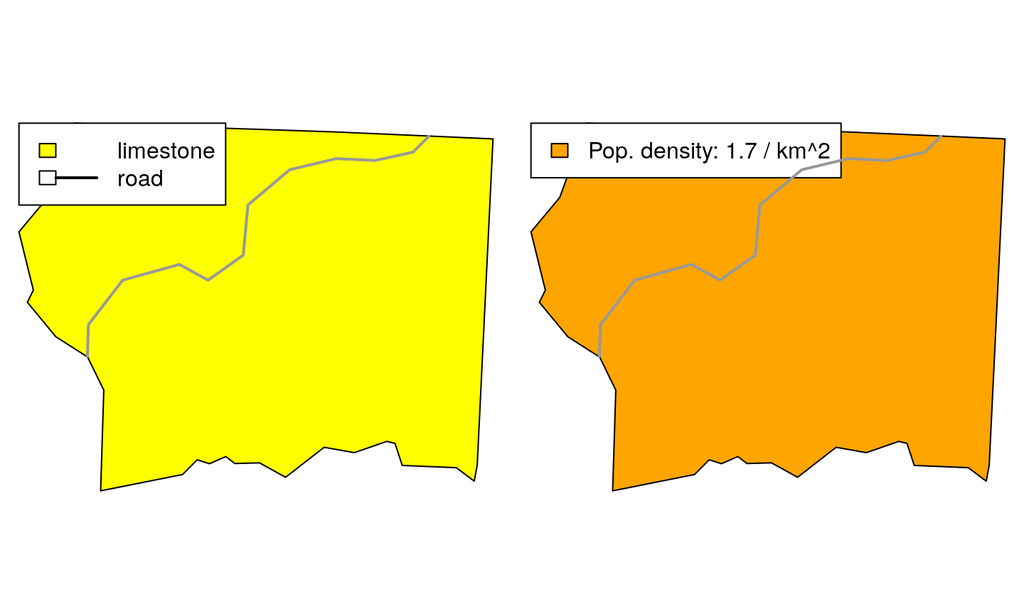

- what is the bedrock type along the grey road?
- what is the population density along the grey road?

## support of data

- a lot of data is not registered for time *instances* or spatial *points*, but rather for time *periods*, and/or spatial *areas*, referred to as *support* of the data
- one can argue that all observation *must* refer to periods/areas, because observation takes time and space, but that doesn't help much
- making the support explicit may help avoid making meaningless analyses

## attribute-geometry relationships

```r
suppressPackageStartupMessages(library(tidyverse))
nc = read_sf(system.file("gpkg/nc.gpkg", package="sf")) %>%
        select(CNTY_, BIR74)
st_agr(nc) = c(CNTY_ = "identity", BIR74 = "aggregate")
pt = st_as_sfc("POINT (-81.49826 36.4314)", crs = st_crs(nc))
i = st_intersection(st_sf(geom = pt), nc)
```

```
## although coordinates are longitude/latitude, st_intersection assumes that they are planar
```

```
## Warning: attribute variables are assumed to be spatially constant
## throughout all geometries
```

We don't get this warning if none of the attributes is an `aggregate`; we're faking this by

```r
st_agr(nc) = c(CNTY_ = "identity", BIR74 = "constant")
i = st_intersection(st_sf(geom = pt), nc)
```

```
## although coordinates are longitude/latitude, st_intersection assumes that they are planar
```

## plotting maps

- plotting spatial data: base, `ggplot2::geom_sf`, raster/stars, mapview, tmap

## measurement units and coordinate reference systems

- attributes: ordinal, nominal, interval, ratio
- reference sytems: units of measurement, datums, coordinate reference systems, calendars, ontologies, …

## coordinate transformations

- `st_crs()` shows, or sets, the coordinate reference system
- `st_transform()` takes care of these, using PROJ strings or EPSG codes (numbers), e.g.

```r
nc = read_sf(system.file("gpkg/nc.gpkg", package="sf"))
nc.tr = st_transform(nc, 2264)
st_crs(nc.tr)
```

```
## Coordinate Reference System:
##   EPSG: 2264
##   proj4string: "+proj=lcc +lat_1=36.16666666666666 +lat_2=34.33333333333334 +lat_0=33.75 +lon_0=-79 +x_0=609601.2192024384 +y_0=0 +ellps=GRS80 +towgs84=0,0,0,0,0,0,0 +units=us-ft +no_defs"
```

```r
st_crs(nc.tr)$units
```

```
## [1] "us-ft"
```

## Raster data

- `sp` has some elementary infrastructure for this (in-memory)
- package `raster` is scalable, solid, and has a large functionality
- `raster` data model: single raster layers, or a stack of raster layers, possibly time-referenced (max: 3-D).
- package `stars` tries to break out of this limitation, and covers raster *and* vector data cubes
- a challenge is always out-of-core computation (data on disk); generic implementation that is still performant is difficult
- e.g. doing time series analysis on NetCDF files series, with one time instance per NetCDF file

## raster grid types

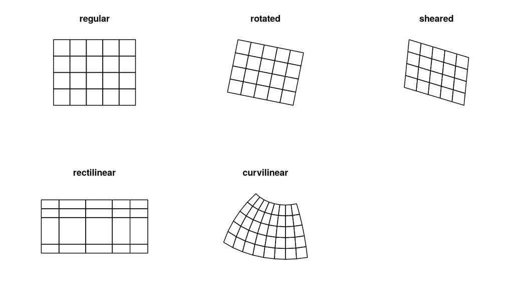

## spatiotemporal (S/T) data

- some S/T data has *irregular* space-time locations, typically in case where the time and location are of primary interest (events): earth quakes, floods, lightning, disease cases, deaths,
- often, such data is aggregated to counts/frequencies/densities per time period and by area, either for privacy or for convenience
- other data is collected at regular space/time combinations (e.g. sensor data, satellite imagery)
- `stars`: a package for raster and vector data cubes, was developed to handle this second case (time instances/periods are identical for all spatial locations/areas)
- a common action is *change* of spatial/temporal resolution (interpolation/downsampling/aggregation)

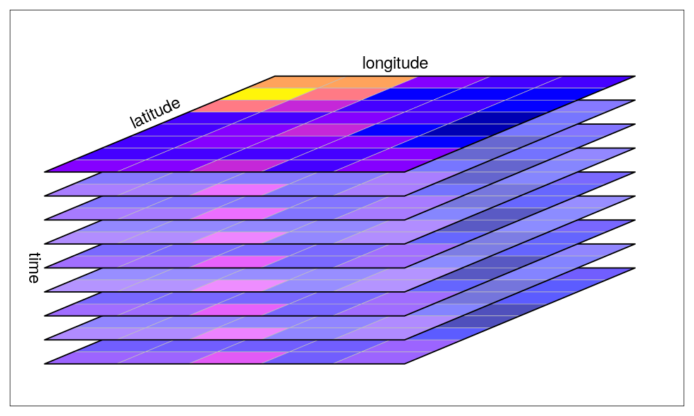

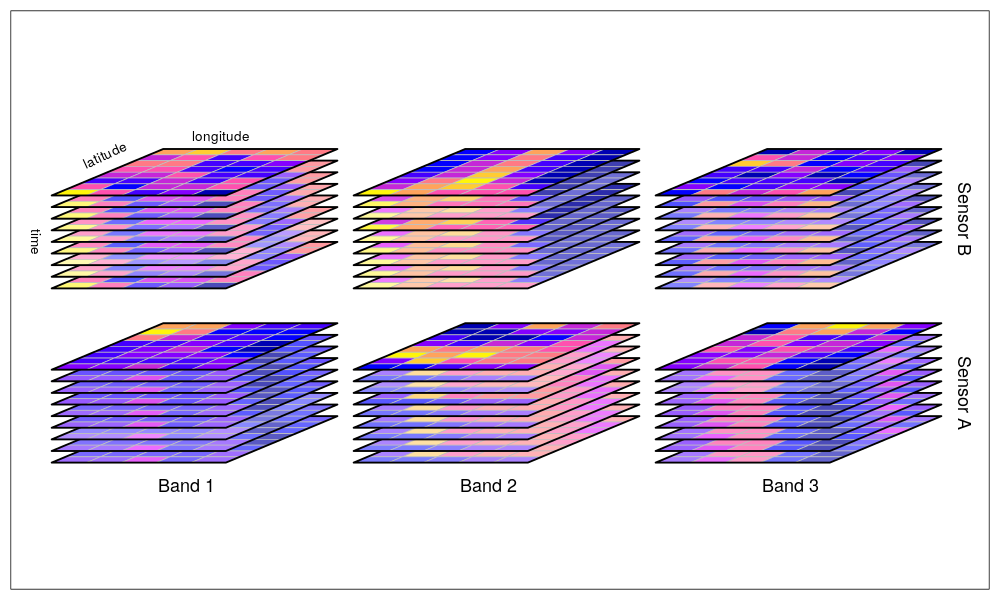

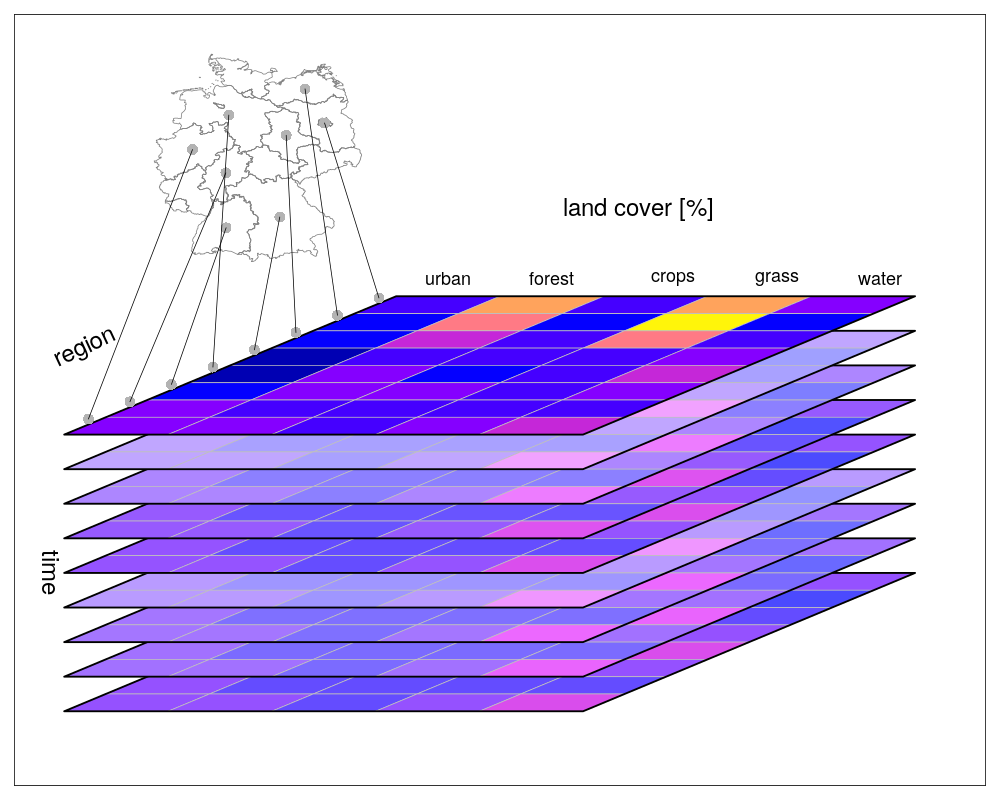

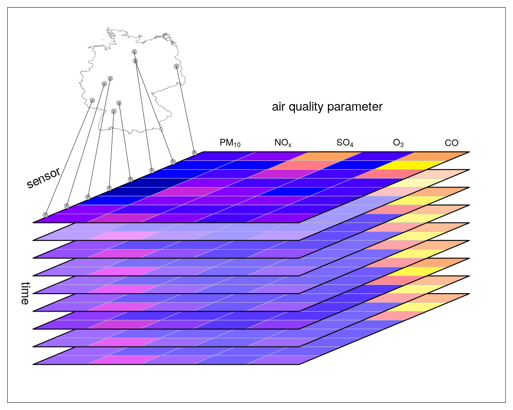

## Data concepts

Data are composed of discrete entities ("numbers, bits")

"Real life" is

- partly discrete (person, house)
- partly less discrete (mountain, flood)
- partly continuous (elevation, air temperature)

S. Scheider, B. Graeler, E. Pebesma, C. Stasch, 2016. Modelling spatio-temporal information generation. Int J of Geographic Information Science, 30 (10), 1980-2008 https://dx.doi.org/10.1080/13658816.2016.1151520 (open access)

## Data concepts (2)

Higher-level concepts:

- Reference systems: Space \(S\), Time \(T\), Discrete \(D\), Quality \(Q\)
- Region \(R\), Period \(P\)
- Object, event \(D \Rightarrow (S,T) \Rightarrow Q\) (marked point pattern)
- Field, Coverage: \(S \Rightarrow Q\), \((S,T) \Rightarrow Q\)
- Trajectory: \(T \Rightarrow S \Rightarrow Q\)
- Aggregation: \((R,P) \Rightarrow Q\)

The concept of a *function* (\(\Rightarrow\)) is largely absent in GIS or data base representations, and neither is that of aggregations as a type.

## Exercises (2)

- Read the file `system.file("tif/L7_ETMs.tif", package = "stars")` with `stars::read_stars`
- print the dataset, and describe what it contains
- plot the dataset; how are the color breaks chosen?
- find the maximum pixel value for each of the bands (`st_apply`)
- find and plot the maximum reflectance over all bands for all pixels
- find and plot the mean reflectance over all bands for all pixels
- plot the subset of these data with the first 10 rows, the second 10 colums, and the last 3 bands
- use `st_crop` to crop the dataset to the area 300 m around `POINT (293749.5 9115745)`
- is this cropped dataset still a (rectangular) raster?